# Google Data Analytics Professional Certificate - Project

Leo Leung

March 2022

## 1. Introduction: Case Study: 12 months of public data, Mar21-Feb22

- My title:
  - **Junior Data Analyst**, *Marketing team*
- Company:
  - **Cyclistic** (fictional), bike-sharing company in Chicago
  - mocking a real-world bike-sharing system in Chicago, [Divvy](https://divvybikes.com/pricing), operated by [Lyft](https://www.lyft.com/bikes/chicago-il/meet-our-bikes)
  - **Data source:** [Divvy Public Data](https://ride.divvybikes.com/system-data)
- What we do:
  - **push-bike** (main) **& e-bike** (growing) **sharing / rentals**
  - **6000 bikes** across **600 docking stations** in Chicago
  - unlock & return bike at any station, **24x7x365**
  - 3 price plans: **Single-ride: $3.30** (30mins inc.) / **24-hour unlimited: $15** / **Annual unlimited: $108 (Members)**

[figure not shown]

## Business Goal

**INCREASE ANNUAL MEMBERSHIP SUBSCRIPTIONS**, as its proven most profitable by our finance analysts. Let’s go through the data analysis process: **A**sk, **P**repare, **P**rocess, **A**nalyse, **S**hare, **A**ct.

## 2. Ask

- bike-sharing has been around Chicago for 10 years since 2012
- Lyft and Divvy have been operating for over 3 years since 2019
- verdict from our Director of Marketing, on our upcoming strategy:
  - **convert casual riders to Annual Members**
  - our brand, and bike-sharing, has been well-known by Chicago citizens
  - looking for new rider to join is not efficient
  - after 10 years of bike-sharing running, if people don’t ride, maybe they just do not

### Project task from Director of Marketing

1. How do annual **members** and **casual** riders use our bikes differently?
2. Why would **casual** riders buy Cyclistic annual memberships?
3. How can Cyclistic use digital media to influence **casual** riders to become **members**?
- Stakeholders for this project:
  - **Director of Marketing**, Lily Moreno
  - **Cyclistic Marketing Analystics team**, which I joined 6 months ago
  - **Cyclistic Executive team**: approval personel of our marketing campaign

## 3. Prepare

- [Divvy Public Data](https://ride.divvybikes.com/system-data) is in `.csv` format
- we can use `SQL` in *BigQuery*, or `R` in R programming. `Spreadsheets` will be too slow to handle
- programming environment chosen: `R` in R Studio

#### Install and load required packages:

```r
# install.packages("janitor") #data cleaning
# install.packages("tidyverse")
library(tidyverse)  #wrangle data
library(lubridate)  #wrangle date attributes
library(skimr)      #stats
library(janitor)    #data cleaning
library(scales) #visuals
# getwd() #displays working directory
```

```r
c1 <- read_csv("202103-divvy-tripdata.csv", show_col_types = FALSE)
c2 <- read_csv("202104-divvy-tripdata.csv", show_col_types = FALSE)
c3 <- read_csv("202105-divvy-tripdata.csv", show_col_types = FALSE)
c4 <- read_csv("202106-divvy-tripdata.csv", show_col_types = FALSE)
c5 <- read_csv("202107-divvy-tripdata.csv", show_col_types = FALSE)
c6 <- read_csv("202108-divvy-tripdata.csv", show_col_types = FALSE)
c7 <- read_csv("202109-divvy-tripdata.csv", show_col_types = FALSE)
c8 <- read_csv("202110-divvy-tripdata.csv", show_col_types = FALSE)
c9 <- read_csv("202111-divvy-tripdata.csv", show_col_types = FALSE)
c10 <- read_csv("202112-divvy-tripdata.csv", show_col_types = FALSE)
c11 <- read_csv("202201-divvy-tripdata.csv", show_col_types = FALSE)
c12 <- read_csv("202202-divvy-tripdata.csv", show_col_types = FALSE)
```

#### Check for column inconsistency for different months

```r
compare_df_cols(c1, c12)
```

```
##           column_name              c1             c12
## 1             end_lat         numeric         numeric
## 2             end_lng         numeric         numeric
## 3      end_station_id       character       character
## 4    end_station_name       character       character
## 5            ended_at POSIXct, POSIXt POSIXct, POSIXt
## 6       member_casual       character       character
## 7             ride_id       character       character
## 8       rideable_type       character       character
## 9           start_lat         numeric         numeric
## 10          start_lng         numeric         numeric
## 11   start_station_id       character       character
## 12 start_station_name       character       character
## 13         started_at POSIXct, POSIXt POSIXct, POSIXt
```

```r
#check all 12 months of data for consistency with the columns
compare_df_cols_same(c1, c2, c3, c4, c5, c6, c7, c8, c9, c10, c11, c12)
```

```
## [1] TRUE
```

#### Combine 12 months of data, into 1 big dataset:

```r
all_trips <- bind_rows(c1, c2, c3, c4, c5, c6, c7, c8, c9, c10, c11, c12)

#inspect the new dataset
skim_without_charts(all_trips)
```

Data summary

| Name | all_trips |
| --- | --- |
| Number of rows | 5667986 |
| Number of columns | 13 |
| _______________________ |  |
| Column type frequency: |  |
| character | 7 |
| numeric | 4 |
| POSIXct | 2 |
| ________________________ |  |
| Group variables | None |

**Variable type: character**

| skim_variable | n_missing | complete_rate | min | max | empty | n_unique | whitespace |
| --- | --- | --- | --- | --- | --- | --- | --- |
| ride_id | 0 | 1.00 | 16 | 16 | 0 | 5667986 | 0 |
| rideable_type | 0 | 1.00 | 11 | 13 | 0 | 3 | 0 |
| start_station_name | 712978 | 0.87 | 3 | 53 | 0 | 853 | 0 |
| start_station_id | 712975 | 0.87 | 3 | 44 | 0 | 844 | 0 |
| end_station_name | 761817 | 0.87 | 10 | 53 | 0 | 854 | 0 |
| end_station_id | 761817 | 0.87 | 3 | 44 | 0 | 846 | 0 |
| member_casual | 0 | 1.00 | 6 | 6 | 0 | 2 | 0 |

**Variable type: numeric**

| skim_variable | n_missing | complete_rate | mean | sd | p0 | p25 | p50 | p75 | p100 |
| --- | --- | --- | --- | --- | --- | --- | --- | --- | --- |
| start_lat | 0 | 1 | 41.90 | 0.05 | 41.64 | 41.88 | 41.90 | 41.93 | 45.64 |
| start_lng | 0 | 1 | -87.65 | 0.03 | -87.84 | -87.66 | -87.64 | -87.63 | -73.80 |
| end_lat | 4617 | 1 | 41.90 | 0.05 | 41.39 | 41.88 | 41.90 | 41.93 | 42.17 |
| end_lng | 4617 | 1 | -87.65 | 0.03 | -88.97 | -87.66 | -87.64 | -87.63 | -87.49 |

**Variable type: POSIXct**

| skim_variable | n_missing | complete_rate | min | max | median | n_unique |
| --- | --- | --- | --- | --- | --- | --- |
| started_at | 0 | 1 | 2021-03-01 00:01:09 | 2022-02-28 23:58:44 | 2021-08-07 19:12:50 | 4747127 |
| ended_at | 0 | 1 | 2021-03-01 00:06:28 | 2022-03-01 08:55:17 | 2021-08-07 19:35:11 | 4740417 |

- Total unique ride_id = total number of rows, means no duplicates
- 3 unique rideable-types, 2 member-types, good data
- station name & id total is different, look LATER1
- station end name & id total is different, look LATER2

#### Add a “ride_length” calculation to all_trips (in **seconds**)

```r
# https://stat.ethz.ch/R-manual/R-devel/library/base/html/difftime.html
all_trips$ride_length <- difftime(all_trips$ended_at,all_trips$started_at)

# inspect
summary(all_trips)
```

```
##    ride_id          rideable_type        started_at
##  Length:5667986     Length:5667986     Min.   :2021-03-01 00:01:09
##  Class :character   Class :character   1st Qu.:2021-06-13 11:41:58
##  Mode  :character   Mode  :character   Median :2021-08-07 19:12:50
##                                        Mean   :2021-08-10 07:33:56
##                                        3rd Qu.:2021-10-02 14:16:11
##                                        Max.   :2022-02-28 23:58:44
##
##     ended_at                   start_station_name start_station_id
##  Min.   :2021-03-01 00:06:28   Length:5667986     Length:5667986
##  1st Qu.:2021-06-13 12:09:22   Class :character   Class :character
##  Median :2021-08-07 19:35:11   Mode  :character   Mode  :character
##  Mean   :2021-08-10 07:55:41
##  3rd Qu.:2021-10-02 14:38:59
##  Max.   :2022-03-01 08:55:17
##
##  end_station_name   end_station_id       start_lat       start_lng
##  Length:5667986     Length:5667986     Min.   :41.64   Min.   :-87.84
##  Class :character   Class :character   1st Qu.:41.88   1st Qu.:-87.66
##  Mode  :character   Mode  :character   Median :41.90   Median :-87.64
##                                        Mean   :41.90   Mean   :-87.65
##                                        3rd Qu.:41.93   3rd Qu.:-87.63
##                                        Max.   :45.64   Max.   :-73.80
##
##     end_lat         end_lng       member_casual      ride_length
##  Min.   :41.39   Min.   :-88.97   Length:5667986     Length:5667986
##  1st Qu.:41.88   1st Qu.:-87.66   Class :character   Class :difftime
##  Median :41.90   Median :-87.64   Mode  :character   Mode  :numeric
##  Mean   :41.90   Mean   :-87.65
##  3rd Qu.:41.93   3rd Qu.:-87.63
##  Max.   :42.17   Max.   :-87.49
##  NA's   :4617    NA's   :4617
```

#### ride_length is in “difftime” class. Convert to “numeric” for calculations

```r
all_trips$ride_length <- as.numeric(as.character(all_trips$ride_length))
is.numeric(all_trips$ride_length) #check again
```

```
## [1] TRUE
```

#### Now look into the dataset:

```r
count(all_trips, rideable_type)
```

```
## # A tibble: 3 x 2
##   rideable_type       n
##   <chr>           <int>
## 1 classic_bike  3268797
## 2 docked_bike    311288
## 3 electric_bike 2087901
```

```r
count(all_trips, member_casual)
```

```
## # A tibble: 2 x 2
##   member_casual       n
##   <chr>           <int>
## 1 casual        2540693
## 2 member        3127293
```

```r
summary(all_trips)
```

```
##    ride_id          rideable_type        started_at
##  Length:5667986     Length:5667986     Min.   :2021-03-01 00:01:09
##  Class :character   Class :character   1st Qu.:2021-06-13 11:41:58
##  Mode  :character   Mode  :character   Median :2021-08-07 19:12:50
##                                        Mean   :2021-08-10 07:33:56
##                                        3rd Qu.:2021-10-02 14:16:11
##                                        Max.   :2022-02-28 23:58:44
##
##     ended_at                   start_station_name start_station_id
##  Min.   :2021-03-01 00:06:28   Length:5667986     Length:5667986
##  1st Qu.:2021-06-13 12:09:22   Class :character   Class :character
##  Median :2021-08-07 19:35:11   Mode  :character   Mode  :character
##  Mean   :2021-08-10 07:55:41
##  3rd Qu.:2021-10-02 14:38:59
##  Max.   :2022-03-01 08:55:17
##
##  end_station_name   end_station_id       start_lat       start_lng
##  Length:5667986     Length:5667986     Min.   :41.64   Min.   :-87.84
##  Class :character   Class :character   1st Qu.:41.88   1st Qu.:-87.66
##  Mode  :character   Mode  :character   Median :41.90   Median :-87.64
##                                        Mean   :41.90   Mean   :-87.65
##                                        3rd Qu.:41.93   3rd Qu.:-87.63
##                                        Max.   :45.64   Max.   :-73.80
##
##     end_lat         end_lng       member_casual       ride_length
##  Min.   :41.39   Min.   :-88.97   Length:5667986     Min.   :  -3482
##  1st Qu.:41.88   1st Qu.:-87.66   Class :character   1st Qu.:    400
##  Median :41.90   Median :-87.64   Mode  :character   Median :    712
##  Mean   :41.90   Mean   :-87.65                      Mean   :   1305
##  3rd Qu.:41.93   3rd Qu.:-87.63                      3rd Qu.:   1294
##  Max.   :42.17   Max.   :-87.49                      Max.   :3356649
##  NA's   :4617    NA's   :4617
```

```r
# total NA is 4617, look LATER3
# "ride_length" is numeric now
```

#### “ride_length” has negatives. Let’s troubleshoot what’s wrong:

```r
temp1 <- filter(all_trips, ride_length < 0)
count(temp1, start_station_name, sort=TRUE)
```

```
## # A tibble: 63 x 2
##    start_station_name               n
##    <chr>                        <int>
##  1 Halsted St & Dickens Ave        32
##  2 <NA>                            20
##  3 Clark St & Newport St            6
##  4 Dayton St & North Ave            5
##  5 New St & Illinois St             5
##  6 Orleans St & Hubbard St          4
##  7 Clybourn Ave & Division St       3
##  8 Damen Ave & Clybourn Ave         3
##  9 Milwaukee Ave & Wabansia Ave     3
## 10 Sheffield Ave & Waveland Ave     3
## # ... with 53 more rows
```

```r
count(temp1, end_station_name, sort=TRUE)
```

```
## # A tibble: 69 x 2
##    end_station_name               n
##    <chr>                      <int>
##  1 Halsted St & Dickens Ave      30
##  2 <NA>                          19
##  3 Dayton St & North Ave          5
##  4 Racine Ave & Fullerton Ave     5
##  5 Michigan Ave & 8th St          4
##  6 Clybourn Ave & Division St     3
##  7 Damen Ave & Clybourn Ave       3
##  8 Leavitt St & Division St       3
##  9 Broadway & Belmont Ave         2
## 10 Broadway & Sheridan Rd         2
## # ... with 59 more rows
```

**Note:** consult team about reason of negative ride time at *Halsted St & Dickens Ave* station. Let’s assume these are bad data first (maybe bikes in repair), and will remove them in the next stage.

[figure not shown]

## 4. Data Cleaning

#### Take a look at the NA stations:

```r
filter(all_trips, is.na(end_station_id)) #~762k results
filter(all_trips, is.na(end_station_name)) #~762k results
filter(all_trips, is.na(start_station_name)) #~713k results
filter(all_trips, is.na(start_station_id)) #~713k results
filter(all_trips, is.na(start_lat)) #zero
filter(all_trips, is.na(start_lng)) #zero
filter(all_trips, is.na(end_lat)) # ~4600 results
filter(all_trips, is.na(end_lng))# ~4600 results

# as we do not know why NA exists, we analyse the ride_length where end_lat is missing
temp2 <-
  filter(all_trips, is.na(end_station_id) & is.na(end_lat))
skim_without_charts(temp2)
```

[output not shown]

- mean for ride_length for “NA” rides, is 71728 seconds.
- We assume that those were bikes returned in abnormal way, thus invalid data
- clean dataset by removing negative ride_length, and remove rides with NA end_lat & lng

#### Remove negative ride_length, and rides lasted less than 10 seconds

```r
all_trips_v2 <- all_trips[!(all_trips$ride_length<10),]

#remove NAs in end_station_id or end_station_name or started_at or ended_at
all_trips_v3 <-
  all_trips_v2[!(is.na(all_trips_v2$end_station_id) | is.na(all_trips_v2$start_station_id) | is.na(all_trips_v2$end_lat) | is.na(all_trips_v2$end_lng)),]
```

*Note:* As bikes unlocked for more than 24 hours are regarded as stolen/lost, although they may be real rides, we want to exclude those for analysis purpose:

```r
all_trips_v3 <-
  all_trips_v3[!(all_trips_v3$ride_length>=86400),]
```

#### Check how many rows / percentage of bad data we removed:

```r
nrow(all_trips)-nrow(all_trips_v3)
```

```
## [1] 1053202
```

```r
(nrow(all_trips)-nrow(all_trips_v3))/nrow(all_trips_v3)*100
```

```
## [1] 22.82235
```

## 5: Analyse the data

#### Add columns that list the date, month, day, and year of each ride

This will allow us to aggregate ride data for each month, day, or year … before completing these operations we could only aggregate at the ride level

```r
# https://www.statmethods.net/input/dates.html more on date formats in R found at that link
all_trips_v3$date <- as.Date(all_trips_v3$started_at) #The default format is yyyy-mm-dd
all_trips_v3$month <- format(as.Date(all_trips_v3$date), "%m")
all_trips_v3$day <- format(as.Date(all_trips_v3$date), "%d")
all_trips_v3$year <- format(as.Date(all_trips_v3$date), "%Y")
all_trips_v3$day_of_week <- format(as.Date(all_trips_v3$date), "%A")
```

#### Compare members and casual users

```r
aggregate(all_trips_v3$ride_length ~ all_trips_v3$member_casual, FUN = mean)
```

```
##   all_trips_v3$member_casual all_trips_v3$ride_length
## 1                     casual                1691.1944
## 2                     member                 785.3618
```

```r
aggregate(all_trips_v3$ride_length ~ all_trips_v3$member_casual, FUN = median)
```

```
##   all_trips_v3$member_casual all_trips_v3$ride_length
## 1                     casual                      997
## 2                     member                      578
```

```r
aggregate(all_trips_v3$ride_length ~ all_trips_v3$member_casual, FUN = max)
```

```
##   all_trips_v3$member_casual all_trips_v3$ride_length
## 1                     casual                    86362
## 2                     member                    85594
```

```r
aggregate(all_trips_v3$ride_length ~ all_trips_v3$member_casual, FUN = min)
```

```
##   all_trips_v3$member_casual all_trips_v3$ride_length
## 1                     casual                       10
## 2                     member                       10
```

#### See the average ride time by each day for members vs casual users

```r
aggregate(all_trips_v3$ride_length ~ all_trips_v3$member_casual + all_trips_v3$day_of_week, FUN = mean)
```

```
##    all_trips_v3$member_casual all_trips_v3$day_of_week all_trips_v3$ride_length
## 1                      casual                   Friday                1569.7401
## 2                      member                   Friday                 765.3109
## 3                      casual                   Monday                1723.1006
## 4                      member                   Monday                 757.8748
## 5                      casual                 Saturday                1824.0939
## 6                      member                 Saturday                 882.7309
## 7                      casual                   Sunday                1943.5831
## 8                      member                   Sunday                 906.0504
## 9                      casual                 Thursday                1446.2415
## 10                     member                 Thursday                 736.4555
## 11                     casual                  Tuesday                1547.2469
## 12                     member                  Tuesday                 736.9268
## 13                     casual                Wednesday                1461.5152
## 14                     member                Wednesday                 741.3034
```

```r
# Notice that the days of the week are out of order. Let's fix that.
all_trips_v3$day_of_week <- ordered(all_trips_v3$day_of_week, levels=c("Sunday", "Monday", "Tuesday", "Wednesday", "Thursday", "Friday", "Saturday"))
```

#### Analyze ridership data by type and weekday

```r
all_trips_v3 %>%
  mutate(weekday = wday(started_at, label = TRUE)) %>%  #creates weekday field using wday()
  group_by(member_casual, weekday) %>%  #groups by usertype and weekday
  summarise(number_of_rides = n()                           #calculates the number of rides and average duration
            ,average_duration = mean(ride_length)) %>%      # calculates the average duration
  arrange(member_casual, weekday)                               # sorts
```

```
## # A tibble: 14 x 4
## # Groups:   member_casual [2]
##    member_casual weekday number_of_rides average_duration
##    <chr>         <ord>             <int>            <dbl>
##  1 casual        Sun              403929            1944.
##  2 casual        Mon              230952            1723.
##  3 casual        Tue              215520            1547.
##  4 casual        Wed              218342            1462.
##  5 casual        Thu              223885            1446.
##  6 casual        Fri              289327            1570.
##  7 casual        Sat              465295            1824.
##  8 member        Sun              314292             906.
##  9 member        Mon              357011             758.
## 10 member        Tue              396209             737.
## 11 member        Wed              402405             741.
## 12 member        Thu              376781             736.
## 13 member        Fri              365856             765.
## 14 member        Sat              354980             883.
```

## 6: Visualisation

#### Visualise the number of rides by rider type

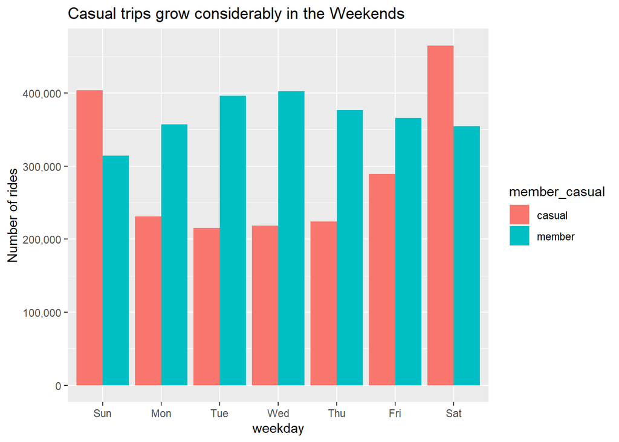

```r
temp1 <- all_trips_v3 %>%
  mutate(weekday = wday(started_at, label = TRUE)) %>%
  group_by(member_casual, weekday) %>%
  summarise(number_of_rides = n()) %>%
  arrange(member_casual, weekday)  %>%
  ggplot(aes(x = weekday, y = number_of_rides, fill = member_casual)) +
  geom_col(position = "dodge")

temp1 + scale_y_continuous(labels = comma, name="Number of rides") +labs(title = "Casual trips grow considerably in the Weekends")
```

#### Create a visualization for average duration

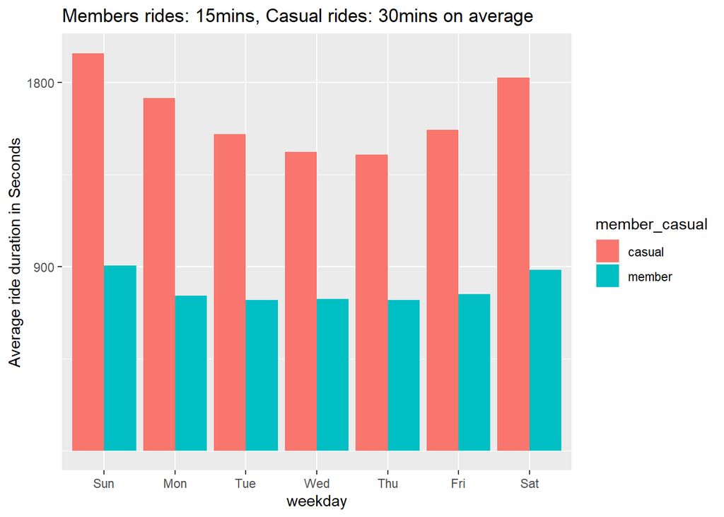

```r
temp2 <- all_trips_v3 %>%
  mutate(weekday = wday(started_at, label = TRUE)) %>%
  group_by(member_casual, weekday) %>%
  summarise(number_of_rides = n()
            ,average_duration_secs = mean(ride_length)) %>%
  arrange(member_casual, weekday)  %>%
  ggplot(aes(x = weekday, y = average_duration_secs, fill = member_casual)) +
  geom_col(position = "dodge")

temp2 + scale_y_continuous(breaks=c(900, 1800), name = "Average ride duration in Seconds") +labs(title ="Members rides: 15mins, Casual rides: 30mins on average")
```

Insight: trip duration on average: * member trips: 10-15mins * casual trips: 23-33mins

## 7: Export summary file for further analysis

#### Create `csv` files that we will visualize in Excel, Tableau, or any presentation software

```r
temp5 <- count(all_trips_v3, day_of_week, rideable_type, member_casual)

temp3 <- aggregate(all_trips_v3$ride_length ~ all_trips_v3$member_casual + all_trips_v3$day_of_week, FUN = mean)

write.csv(temp5, file = 'temp5.csv') #replace with your own location
write.csv(temp3, file = 'temp3.csv') #replace with your own location

#temp4 <- all_trips_v3
#write.csv(temp4, file = 'all_trips3.csv')
```

#### Import custom `.csv` generated to Tableau, for insights.

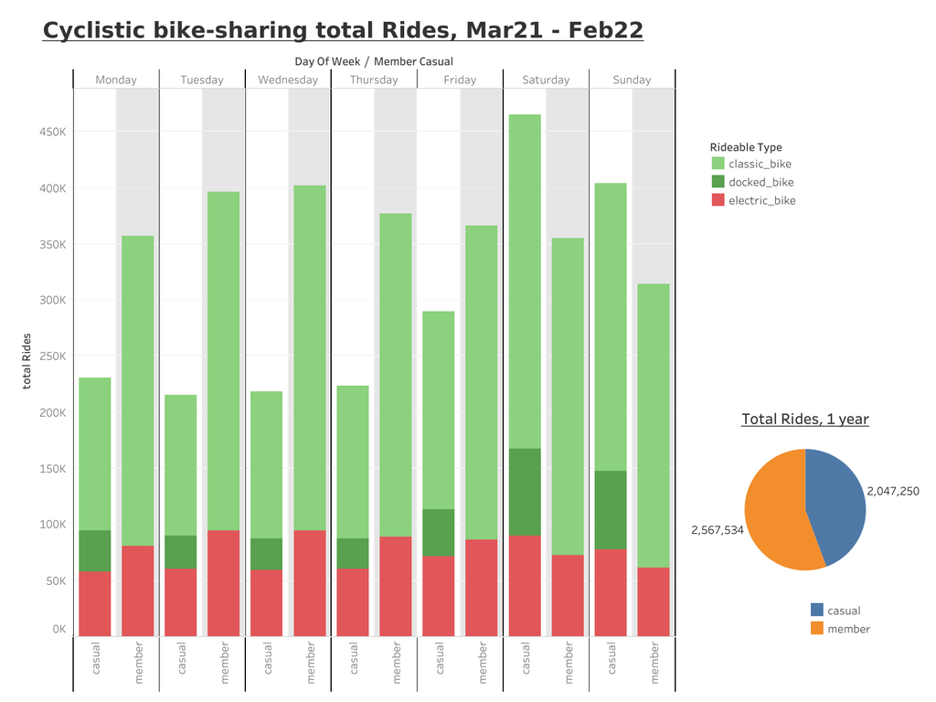

## 8. Act

#### Marketing Strategy

- **physically promote membership sign-ups right at our 600+ bike docks**
- **only promote on weekends to attract the most casual riders**
- **cost effective strategy**

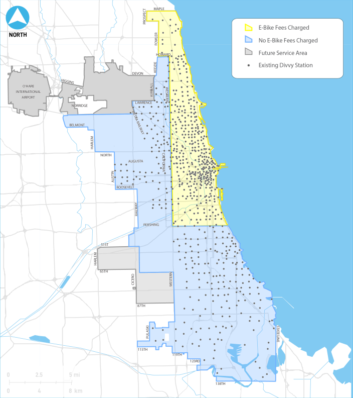